# US Beers and Breweries

BeerVana Consulting Group - Christopher Morgan, Dmitry Andreev, & Eduardo Cantu

February 17, 2018

# Introduction

As we enter 2018, with nearly 6,000 microbreweries registered in the U.S., it is safe to say that craft brews are all the craze and they’re here to stay. When was the last you can remember reaching for a Miller Light after leaving college? Sure, this could be due to the fact you can finally afford to pay more than $1.50 for a canned beer and are starting to get curious about trying something new. At BeerVana Consulting we believe that the real driving force behind this trend is the unmatched variety of flavors that you simply can’t find with the Budweisers, Coors, and Heinekens of the world. Not only are there an endless array of hole-in-the-wall breweries popping up on every town corner but also the ever-increasing competition to make new brews that cater to this new class of beer snob elites has never been fiercer. Lucky for them, we have narrowed down the main preferences for each state. So for any new players looking to enter the craft brewery game, rest assured that Beervana is taking out the guesswork for you and your next brew! The goal of this report is to simplify the large sea of information currently available for some of the most popular craft breweries in each state and the most popular canned beers they’re putting out. We also dive into a rather surprising relationship that exists between the ABV (Alcohol by Volume) and IBU (International Bitterness Unit) for these beers.

## Data Description

The datasets being used for this report were sourced from the CraftCans website. It only contains data for canned beers from craft breweries in the United States. It is not clear from the website if this dataset reports every single canned beer brewed in the US or not. There are also several attributes of the listed beers that have missing information so for this reason we will consider this dataset to be a sample that may contain biases.

The two datasets that will be referred and used throughout this report are summarized below:

### 1 Beers.csv:

| Field Name | Field Description |
| --- | --- |
| Name: | Name of the beer. |
| Beer ID: | Unique identifier of the beer. |
| ABV: | Alcohol by volume of the beer. |
| IBU: | International Bitterness Units of the beer. |
| Brewery ID: | Brewery id associated with the beer. |
| Style: | Style of the beer. |
| Ounces: | Ounces of beer. |

### 2 Breweries.csv:

| Field Name | Field Description |
| --- | --- |
| Brew ID: | Unique identifier of the brewery. |
| Name: | Name of the brewery. |
| City: | City where the brewery is located. |
| State: | U.S. State where the brewery is located. |

### Data Load

Our first set of code loads in the data, does some early data organization for mergin the data, and adds in some basic fields for state tracking

```r
#Read Data into Variables
beers <- read.csv("Beers.csv")
breweries <-read.csv("Breweries.csv")

#Rename beers name column to beerName
colnames(beers)[1] <- c("beerName")

#Rename brewery name column to brewerCompany
colnames(breweries)[2] <- c("brewerCompany")

#Rename Brewery_id to Brew_id in beers data, same as in breweries in order to merge data sets
colnames(beers)[5] <- c("Brew_ID")

# Trim the leading white-space from the State
breweries$State <- trimws(breweries$State)

#Create State Names data frame, inlcuding Washington DC
stateNames <- data.frame(stateName=c(state.name,"Washington DC"),State=c(state.abb,"DC"))

# add the State Name to the Breweries Data Frame
breweries <- merge(breweries,stateNames,by="State", all=TRUE)
```

### Data Cleaning for Breweries

Here we begin the process of cleaning our brewery data. We first trim out white space and lower all text in the brewery data to prevent false positives when searching for duplicates. Next, we perform a duplicate analysis that eliminates likely duplicate breweries by searching for rows of data that have the first two words matching in brewery name, and the brewery data share the same city.

```r
####this area cleans the brewrery data of most likely duplicate entries####
#loads stringr funtion
library(stringr)
#creates work area for brewries data with b df
b<-breweries
#trims b of white space and converts to lowercase
sapply(b,FUN = trimws)
sapply(b,FUN = tolower)
#pulls first two words from brewery data to eliminate potential duplicates and creates it as a column in b
b$TwoWords<-word(b$brewerCompany,1,2,sep=" ")
#eliminates duplicate data where duplicate brewries share the same name and are in the same city
uniqueBreweries <- b[!duplicated(b[,c("TwoWords", "City")]),]
```

# Questions of Interest

## 1. How many breweries are present in each state?

To obtain a count of breweries by state, we use some of our previous work in the cleaning phase to perform a count by state calculation.  
The number of breweries per state ranges from 1 to 47 breweries. Below is the list of states order from the highest to the lowest numbers of breweries in it. Colorado is the state with the most brewer companies. On the other hand, North Dakota, South Dakota, Washington DC, and West Virginia are the states with only one craft brewer company.

```r
#Plot Library
library(ggplot2)

# Count Breweries per State
countBrewByState <- table(uniqueBreweries$stateName)
countBrewByState <- as.data.frame(countBrewByState)
colnames(countBrewByState)=c("stateName","BreweriesCount")
sort.countBState <- countBrewByState[order(-countBrewByState$BreweriesCount),]
sort.countBState
```

|  | stateName | BreweriesCount |
| --- | --- | --- |
| 6 | Colorado | 47 |
| 5 | California | 39 |
| 22 | Michigan | 31 |
| 37 | Oregon | 29 |
| 43 | Texas | 27 |
| 38 | Pennsylvania | 25 |
| 21 | Massachusetts | 23 |
| 47 | Washington | 23 |
| 14 | Indiana | 22 |
| 33 | North Carolina | 19 |

[output cut: 41 more lines]

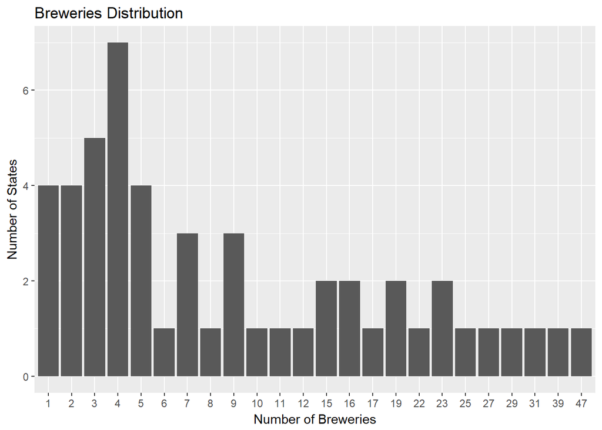

```r
#Create frequncy per Number of Breweries and bar Plot
statehis.df <- as.data.frame(table(countBrewByState$BreweriesCount))
ggplot(data=statehis.df, aes(x=statehis.df$Var1,y=statehis.df$Freq)) +
  geom_bar(stat="identity") +
  ggtitle("Breweries Distribution") + xlab("Number of Breweries") + ylab("Number of States")
```

It is important to note that this dataset is only a sample containing 558 out of over 6,000 craft breweries registered in the US. After conducting preliminary research on several online databases such as BreweryDB and Untappd, Beervana Consulting Group feels that this sample provides a good starting point for understanding the geographic distribution of craft breweries around the country. Another point to note is that Washington DC was treated as a separate state which is the reason for having a total of 51 states in the table above as well as the plot below. Rather than including DC within Virginia or Maryland and overestimating their brewery count, we decided to provide some visibility to DC in case there was a specific interest to further research the area.

## 2. Merge beer data with the breweries data. Print the first 6 observations and the last six observations to check the merged file.

Here we merge the raw beer and brewery data. We have intentionally used the raw brewery data here since it ensure all beers are present for the future analysis. Analysis that requires unique breweries can be called using early cleaned datasets.

```r
#Merge beers and breweries data together
m1 <- merge(beers,breweries,by="Brew_ID")
```

```r
#performs search for parenthesis values, removes them from a nondestructive column for beers
m1$beerNameNoY<-gsub("[:(:].*[:):]","",m1$beerName)
#trims white space around newly trimmed data for beers
m1$beerNameNoY<-trimws(m1$beerNameNoY)
#eliminates duplicates for beers
m1 <- m1[!duplicated(m1[,c("beerNameNoY","brewerCompany","ABV","IBU","Style")]),]

#Table with the first 6 observations from m1 (merged data)
head(m1)
```

|  | Brew_ID | beerName | Beer_ID | ABV | IBU | Style | Ounces | State | brewerCompany | City | stateName | beerNameNoY |
| --- | --- | --- | --- | --- | --- | --- | --- | --- | --- | --- | --- | --- |
| 1 | 1 | Get Together | 2692 | 0.045 | 50 | American IPA | 16 | MN | NorthGate Brewing | Minneapolis | Minnesota | Get Together |
| 2 | 1 | Maggie's Leap | 2691 | 0.049 | 26 | Milk / Sweet Stout | 16 | MN | NorthGate Brewing | Minneapolis | Minnesota | Maggie's Leap |
| 3 | 1 | Wall's End | 2690 | 0.048 | 19 | English Brown Ale | 16 | MN | NorthGate Brewing | Minneapolis | Minnesota | Wall's End |
| 4 | 1 | Pumpion | 2689 | 0.060 | 38 | Pumpkin Ale | 16 | MN | NorthGate Brewing | Minneapolis | Minnesota | Pumpion |
| 5 | 1 | Stronghold | 2688 | 0.060 | 25 | American Porter | 16 | MN | NorthGate Brewing | Minneapolis | Minnesota | Stronghold |
| 6 | 1 | Parapet ESB | 2687 | 0.056 | 47 | Extra Special / Strong Bitter (ESB) | 16 | MN | NorthGate Brewing | Minneapolis | Minnesota | Parapet ESB |

```r
#Table with the last 6 observations from m1 (merged data)
tail(m1)
```

|  | Brew_ID | beerName | Beer_ID | ABV | IBU | Style | Ounces | State | brewerCompany | City | stateName | beerNameNoY |
| --- | --- | --- | --- | --- | --- | --- | --- | --- | --- | --- | --- | --- |
| 2405 | 556 | Pilsner Ukiah | 98 | 0.055 | NA | German Pilsener | 12 | CA | Ukiah Brewing Company | Ukiah | California | Pilsner Ukiah |
| 2406 | 557 | Heinnieweisse Weissebier | 52 | 0.049 | NA | Hefeweizen | 12 | NY | Butternuts Beer and Ale | Garrattsville | New York | Heinnieweisse Weissebier |
| 2407 | 557 | Snapperhead IPA | 51 | 0.068 | NA | American IPA | 12 | NY | Butternuts Beer and Ale | Garrattsville | New York | Snapperhead IPA |
| 2408 | 557 | Moo Thunder Stout | 50 | 0.049 | NA | Milk / Sweet Stout | 12 | NY | Butternuts Beer and Ale | Garrattsville | New York | Moo Thunder Stout |
| 2409 | 557 | Porkslap Pale Ale | 49 | 0.043 | NA | American Pale Ale (APA) | 12 | NY | Butternuts Beer and Ale | Garrattsville | New York | Porkslap Pale Ale |
| 2410 | 558 | Urban Wilderness Pale Ale | 30 | 0.049 | NA | English Pale Ale | 12 | AK | Sleeping Lady Brewing Company | Anchorage | Alaska | Urban Wilderness Pale Ale |

As you scroll along the columns of each list, you will notice that there are now numerous attributes included in the merged dataset to describe each beer. You can begin to get a good idea of which brewery, city, and state the beer orginated from along with other details such as the size, style, alcohol content, and how bitter it is. Clearly, the merged dataset proves to be more valuable in exploring and understanding the distribution of the US craft beers and breweries that they come from along with any underlying relationships that exist within.

## 3. Report the number of NA’s in each column.

One of our biggest challenges with this dataset is understanding how best to handle any missing data. To begin with, we simply summarized the number of NA’s or missing values for each column of the merged dataset. This way we can evaluate the quality of the data and try to account for any issues this may result in during analysis.

```r
# This will count NA per field
NACount <- sapply(m1,function(x) sum(is.na(x)))
NACount <- as.data.frame(NACount)
colnames(NACount)=c("CountOfNAs")
NACount
```

|  | CountOfNAs |
| --- | --- |
| Brew_ID | 0 |
| beerName | 0 |
| Beer_ID | 0 |
| ABV | 62 |
| IBU | 966 |
| Style | 0 |
| Ounces | 0 |
| State | 0 |
| brewerCompany | 0 |
| City | 0 |

[output cut: 2 more lines]

The “IBU” field has 966 empty values which is 40% of our dataset. BeerVana Consulting strongly recommends that we further research these values and try to account for them prior to making any decisions. In contrast we have the “ABV” with 62 empty values, which represent 2.5% of our dataset, this number should not skew our data analysis for ABV.

## 4. Compute the median alcohol content and international bitterness unit for each state. Plot a bar chart to compare.

Median alcohol content is computed using our merged dataset and then printed using a built-in function from the ggplot package. The results show that the median ABV (Alcohol By Volume) ranges from 4% to 6.25% from state to state. The 2.5% missing values on ABV are not enough to affect the outcome of these median values.

However, the IBU median calculation may not be accurate due to the previously mentioned 40% missing values in the dataset. Even though the median can be calculated, this may somewhat differ from the overall population of 6,000 US craft breweries. The states’ median IBU values range anywhere from 0 to 61. We did notice that South Dakota has a calculated median IBU of 0 because it is missing all the IBU data. There may be states that have enough missing IBU values to change their median outcome.

```r
# ABV Median Calculation per State and Column Renames. NA Values are ignored.
med.st.abv<-aggregate(m1$ABV~m1$State,m1,median,na.rm=T)
colnames(med.st.abv)<- c("State","ABV")
# Sort the data for ABV
med.st.abv <- med.st.abv[order(med.st.abv$ABV),]
# Change the scale for the ABV to percentage
med.st.abv$ABV <- med.st.abv$ABV*100
# IBU Median Calculation per State and Column Renames. NA Values are ignored.
med.st.ibu<-aggregate(m1$IBU~m1$State,m1,median,na.rm=T)
colnames(med.st.ibu)<- c("State","IBU")


#NA for SD binded back in as 0 value
sdrow<-list('SD',0)
med.st.ibu<-rbind(med.st.ibu,sdrow)

# Sort the data for IBU
med.st.ibu <- med.st.ibu[order(med.st.ibu$IBU),]

# ABV Median per State
med.st.abv
```

|  | State | ABV |
| --- | --- | --- |
| 45 | UT | 4.00 |
| 32 | NJ | 4.60 |
| 17 | KS | 5.00 |
| 29 | ND | 5.00 |
| 51 | WY | 5.00 |
| 22 | ME | 5.10 |
| 3 | AR | 5.20 |
| 19 | LA | 5.20 |
| 25 | MO | 5.20 |
| 49 | WI | 5.20 |

[output cut: 41 more lines]

```r
# IBU Median per State
med.st.ibu
```

|  | State | IBU |
| --- | --- | --- |
| 51 | SD | 0.0 |
| 7 | CT | 18.0 |
| 4 | AZ | 21.0 |
| 50 | WY | 21.0 |
| 17 | KS | 22.0 |
| 12 | HI | 23.5 |
| 25 | MO | 24.0 |
| 40 | RI | 24.0 |
| 48 | WI | 24.0 |
| 13 | IA | 25.0 |

[output cut: 41 more lines]

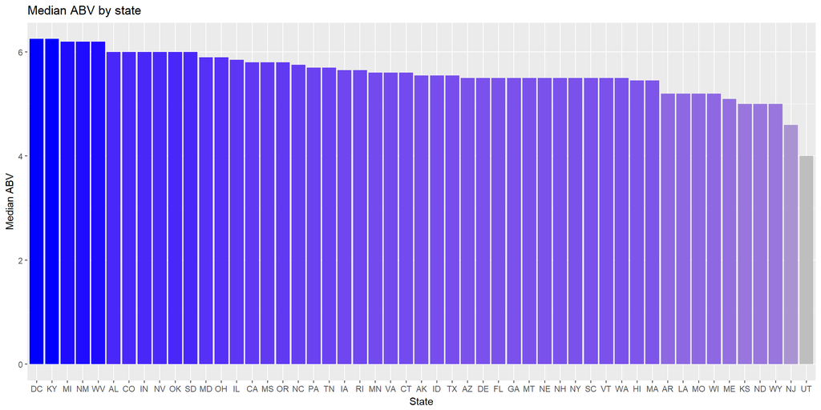

```r
##Histograms, Raw Data

ggplot(data=med.st.abv, aes(x=reorder(med.st.abv$State,-med.st.abv$ABV), y=med.st.abv$ABV, fill=med.st.abv$ABV)) +
  geom_bar(stat="identity") +
  ggtitle("Median ABV by state") +
  xlab("State") + ylab("Median ABV") +guides(fill=FALSE) + scale_fill_gradient(low = "grey",high="blue")
```

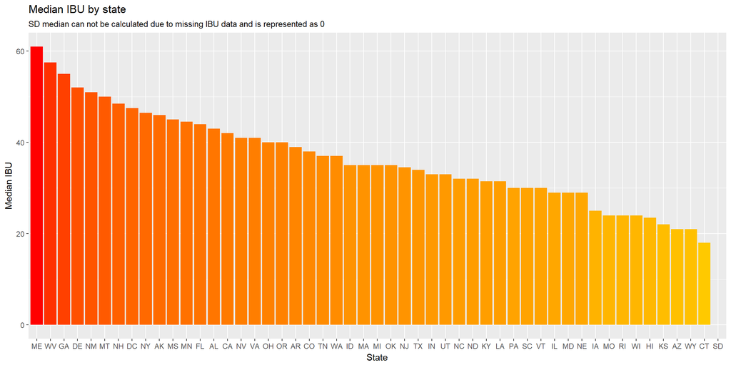

```r
ggplot(data=med.st.ibu, aes(x=reorder(med.st.ibu$State,-med.st.ibu$IBU),y=med.st.ibu$IBU, fill=med.st.ibu$IBU)) + geom_bar(stat = "identity") +
  ggtitle("Median IBU by state", subtitle = "SD median can not be calculated due to missing IBU data and is represented as 0") +
  xlab("State") + ylab("Median IBU") +guides(fill=FALSE) + scale_fill_gradient(low = "yellow",high="Red")
```

## 5. Which state has the maximum alcoholic (ABV) beer? Which state has the most bitter (IBU) beer?

Next, we calculated the maximum ABV and IBU and printed the results for each state. Colorado has the brewery that produces the highest Alcohol By Volume beer. Even though the 2.5% missing data may take Colorado’s claim of having the highest ABV beer, the probability is low. However, we cannot say the same for the IBU first place. Oregon, the state with the highest IBU beer title, may not be a valid conclusion. With 40% missing data, there may be other states out there with beers that have an IBU far higher than what we found in this case for Oregon.

```r
# Change the ABV Scale to percent
m1$ABV<- m1$ABV*100
# Find the State with the maximum ABV beer
z<-which.max(m1$ABV)

paste(m1$stateName[z], "has the highest ABV with a Max ABV of:", m1$ABV[z])
```

```
## [1] "Colorado has the highest ABV with a Max ABV of: 12.8"
```

```r
# Find the State with the highest bitterness (IBU) beer
y<-which.max(m1$IBU)
paste(m1$stateName[y], "has the highest IBU with a Max IBU of:", m1$IBU[y])
```

```
## [1] "Oregon has the highest IBU with a Max IBU of: 138"
```

## 6. Summary statistics for the ABV variable.

Referencing our joined dataset, we can print summary statistics for ABV. From the summary statistics, it can be inferred that the ABV of our craft beers dataset follows a normal distribution because the median and the mean values are very close. There is a slight right skew to the data, but nothing that will indicate an extreme departure from normality. One thing to notice is that 75% of all the beers have a 5% ABV or more. However, the interquartile distance is only 1.8% suggesting that 50% of the data is bounded between 5% and 6.8% ABV.  
You might notice that the number of NA’s for the ABV variable is shown in the output below. It is important to remember that these missing values are not included in the summary statistics but as previously mentioned, we feel that this only accounts for 2.5% of the overall dataset and should have influence the statistics of interest.

```r
# Summary for ABV Values
summary(m1$ABV)
```

```
##    Min. 1st Qu.  Median    Mean 3rd Qu.    Max.    NA's
##   0.100   5.000   5.600   5.987   6.800  12.800      62
```

## 7. Is there an apparent relationship between the bitterness of the beer and its alcoholic content? Draw a scatter plot. You are welcome to use the ggplot2 library for graphs. Please ignore missing values in your analysis. Make your best judgment of a relationship and explain your answer.

There is a caveat to keep in mind for this regression analysis that 40% of the IBU data is missing. This could be strongly influencing the regression coefficients since currently there is no way of knowing exactly where that 40% falls within the overall spectrum of IBU values for all craft beers in the US. Please keep this in mind when looking at the regression analysis presented below.

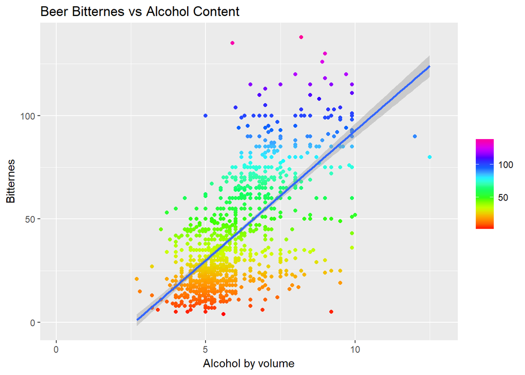

```r
ggplot(data=m1,aes(x=m1$ABV,y=m1$IBU,colour=m1$IBU)) + geom_point() + geom_smooth(method="lm", formula=y~x) +
  xlab("Alcohol by volume") + ylab("Bitternes") + ggtitle("Beer Bitternes vs Alcohol Content") +
  scale_colour_gradientn(colours = rainbow(10)) + theme(legend.title=element_blank())
```

```r
mod = lm(m1$IBU ~ m1$ABV, data = m1)
summary(mod)
```

```
##
## Call:
## lm(formula = m1$IBU ~ m1$ABV, data = m1)
##
## Residuals:
##     Min      1Q  Median      3Q     Max
## -77.655 -12.187  -1.319  13.732  93.762
##
## Coefficients:
##             Estimate Std. Error t value Pr(>|t|)
## (Intercept) -32.8107     2.4762  -13.25   <2e-16 ***
## m1$ABV       12.5506     0.4018   31.24   <2e-16 ***
## ---
## Signif. codes:  0 '***' 0.001 '**' 0.01 '*' 0.05 '.' 0.1 ' ' 1
##
## Residual standard error: 19.41 on 1229 degrees of freedom
##   (966 observations deleted due to missingness)
## Multiple R-squared:  0.4426, Adjusted R-squared:  0.4421
## F-statistic: 975.8 on 1 and 1229 DF,  p-value: < 2.2e-16
```

# Conclusion

This study unveils several interesting insights regarding the geographic distribution of US craft breweries along with some of the more important characteristics of the beers they brew. There is clearly a large variation in the number of breweries present in each state. This could be reflective of the more pronounced brewing and drinking culture of the respective state or possibly a high quality distribution infrastructure that brings down the overall costs for new and expanding breweries.

Taking a closer look at the craft beers that these breweries are putting out, we found that the median ABV and IBU values for each state also tend to differ. Intuitively, you would think that the ABV would trend with the number of breweries, however, this was not the case. For example, Kentucky was on the low end of brewery count with only 4, actually came in as the state with the highest median ABV at 6.25%. After conducting further research on Kentucky’s alcohol laws, we found that approximately 39 counties in the state (mostly eastern and souther counties) are dry meaning that all alcohol sale and possession is prohibited. This reveals that it would only take a couple of breweries putting out high ABV beers to skew the overall median value for Kentucky. The same median ABV would be a lot more difficult to achieve for a state such as Colorado with 47 breweries represented in this dataset.

When turning our attention over to the IBU of craft beers, we didn’t expect there to be a relationship with number of breweries per state. What we found was that the IBU is very much a taste preference of the consumers and possibly climate because the colder North-Eastern states such as Maine produced rather bitter IPA beers while the warmer Southern states such as Arizona sided with the milder Blonde Ales that barely have a hint of bitterness. It is important to note that 40% of the IBU values were missing within this dataset which could be strongly influencing the overall and median IBU values for each state. South Dakota is a great example since it actually doesn’t have any IBU values recorded for it’s craft beers. For this reason, we believe that further research is needed into understanding why the IBU data is missing and how best to account for these values.

Now that we have a preliminary understanding of which states have the higher number of breweries and what their respective ABV and IBU preferences, our recommendation is to establish specific goals for further research be it opening a new brewery or producing the best tasting brew in the state.